# 0. Introduction

# 5. Model Training

Oversampling the minority class before cross-validation alters the dataset's distribution, potentially impacting the performance estimates obtained from cross-validation. Since synthetic samples are generated to balance class distribution, the model may become overconfident in its predictions, leading to overly optimistic performance estimates. Additionally, if oversampling is performed before splitting the data into folds for cross-validation, it could introduce data leakage, as information from the validation folds might leak into the training folds, biasing the performance estimates.

```python
# Define the number of folds for cross-validation
k = 5
skf = StratifiedKFold(n_splits=k, shuffle=True, random_state=42)
```

```python
# Initialize logistic regression classifier
lr_classifier = LogisticRegression()
```

```python
# Define hyperparameters for tuning
param_grid = {'C': [0.1, 1, 10], 'penalty': ['l1', 'l2']}
```

```python
# Perform k-fold cross-validation with SMOTE oversampling and hyperparameter tuning
best_model = None
best_score = 0
for train_index, val_index in skf.split(X_train, y_train):
    X_train_fold, X_val_fold = X_train.iloc[train_index], X_train.iloc[val_index]
    y_train_fold, y_val_fold = y_train.iloc[train_index], y_train.iloc[val_index]

    # Apply SMOTE oversampling to the training fold
    smote = SMOTE(random_state=42)
    X_train_resampled, y_train_resampled = smote.fit_resample(X_train_fold, y_train_fold)

    # Perform hyperparameter tuning using GridSearchCV
    grid_search = GridSearchCV(lr_classifier, param_grid, cv=3, scoring='accuracy')
    grid_search.fit(X_train_resampled, y_train_resampled)

    # Select the best model based on validation score
    if grid_search.best_score_ > best_score:
        best_score = grid_search.best_score_
        best_model = grid_search.best_estimator_
```

[output not shown]

[output cut: 445 more lines]

[output not shown]

```python
# Train the final model on the entire training set
best_model.fit(X_train_resampled, y_train_resampled)
```

```
LogisticRegression(C=10)
```

```python
# Evaluate the final model on the testing set
y_pred = best_model.predict(X_test)
accuracy = accuracy_score(y_test, y_pred)
print("Accuracy on testing set:", accuracy)
```

```
Accuracy on testing set: 0.6878512919871856
```

```python
# Calculate confusion matrix
conf_matrix = confusion_matrix(y_test, y_pred)
print("Confusion Matrix:")
print(conf_matrix)
```

```
Confusion Matrix:
[[34879 15867]
 [  405   978]]
```

From this confusion matrix:

The model correctly identified a large number of non-default cases (34879) but also misclassified a considerable number of non-default cases as default (15867). It correctly identified a relatively small number of default cases (978) but also misclassified some default cases as non-default (405).

```python
# Calculate precision, recall, and f1-score
precision = precision_score(y_test, y_pred)
recall = recall_score(y_test, y_pred)
f1 = f1_score(y_test, y_pred)

print("Precision:", precision)
print("Recall:", recall)
print("F1-Score:", f1)
```

```
Precision: 0.05805877114870882
Recall: 0.7071583514099783
F1-Score: 0.10730743910467413
```

Precision: The precision of approximately 0.058 indicates that only about 5.8% of the predicted positive cases are truly positive. In the context of credit risk prediction, this means that the model's predictions of defaulting applicants have a relatively high rate of false positives, indicating that many applicants predicted to default actually do not default.

Recall: The recall of approximately 0.707 suggests that the model captures around 70.7% of the true positive cases. This means that the model correctly identifies a relatively high proportion of the actual defaulting applicants, indicating a good ability to detect positive cases.

F1-Score: The F1-score of approximately 0.107 reflects the harmonic mean of precision and recall. This score indicates the balance between precision and recall. While the recall is relatively high, the low precision significantly impacts the F1-score, highlighting the model's overall performance issues.

Conclusion: The model exhibits a high recall rate, indicating its ability to detect true positive cases effectively. However, the low precision and F1-score suggest a substantial number of false positives, indicating that the model's predictions of defaulting applicants are not reliable. Therefore, while the model may effectively identify a large proportion of actual default cases, it also produces a considerable number of false alarms, potentially leading to rejecting deserving applicants or making poor lending decisions. Further optimization of the model is necessary to improve its precision and overall performance in credit risk prediction.

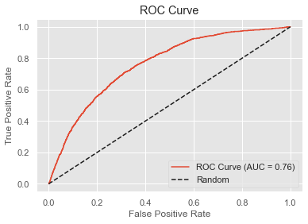

```python
# Compute predicted probabilities
y_pred_proba = best_model.predict_proba(X_test)[:, 1]

# Calculate ROC curve and AUC
fpr, tpr, thresholds = roc_curve(y_test, y_pred_proba)
auc = roc_auc_score(y_test, y_pred_proba)

# Plot ROC curve
plt.plot(fpr, tpr, label='ROC Curve (AUC = {:.2f})'.format(auc))
plt.plot([0, 1], [0, 1], 'k--', label='Random')
plt.xlabel('False Positive Rate')
plt.ylabel('True Positive Rate')
plt.title('ROC Curve')
plt.legend()
plt.show()
```

Given that the AUC is around 0.76, indicating a moderately effective model, I decided to employ a boosting algorithm to further enhance our model's performance. Boosting techniques iteratively build multiple weak models, focusing on instances that were misclassified in previous iterations. This approach aims to improve the overall predictive accuracy of the model, particularly in discriminating between default and non-default instances.

# 5. XGBoost

```python
# Define the XGBoost model
xgb_classifier = xgb.XGBClassifier(objective='binary:logistic', random_state=42)
```

Define the hyperparameters for tuning.

```python
param_grid = {'learning_rate': [0.1, 0.01, 0.001],
              'max_depth': [3, 5, 7],
              'n_estimators': [50, 100, 200]}
```

Perform K-fold cross-validation with SMOTE oversampling and hyperparameter tuning using GridSearchCV.

```python
best_model = None
best_score = 0
for train_index, val_index in skf.split(X_train, y_train):
    X_train_fold, X_val_fold = X_train.iloc[train_index], X_train.iloc[val_index]
    y_train_fold, y_val_fold = y_train.iloc[train_index], y_train.iloc[val_index]

    # Apply SMOTE oversampling to the training fold
    smote = SMOTE(random_state=42)
    X_train_resampled, y_train_resampled = smote.fit_resample(X_train_fold, y_train_fold)

    # Perform hyperparameter tuning using GridSearchCV
    grid_search = GridSearchCV(xgb_classifier, param_grid, cv=3, scoring='accuracy')
    grid_search.fit(X_train_resampled, y_train_resampled)

    # Select the best model based on validation score
    if grid_search.best_score_ > best_score:
        best_score = grid_search.best_score_
        best_model = grid_search.best_estimator_
```

Evaluate the final model on the testing set

```python
y_pred = best_model.predict(X_test)
accuracy = accuracy_score(y_test, y_pred)
print("Accuracy on testing set:", accuracy)
```

```
Accuracy on testing set: 0.9786107540908132
```

```python
# Calculate confusion matrix
conf_matrix = confusion_matrix(y_test, y_pred)
print("Confusion Matrix:")
print(conf_matrix)
```

```
Confusion Matrix:
[[50421   325]
 [  790   593]]
```

From this confusion matrix:

The model correctly identified a large number of non-default cases (50421) and relatively few false positives (325). It correctly identified some default cases (593) but also misclassified a considerable number of default cases as non-default (790).

Overall, the confusion matrix suggests that the XGBoost model has improved performance compared to the previous model, with a reduced number of false positives.

```python
# Calculate precision, recall, and f1-score
precision = precision_score(y_test, y_pred)
recall = recall_score(y_test, y_pred)
f1 = f1_score(y_test, y_pred)

print("Precision:", precision)
print("Recall:", recall)
print("F1-Score:", f1)
```

```
Precision: 0.6459694989106753
Recall: 0.4287780187997108
F1-Score: 0.5154280747501088
```

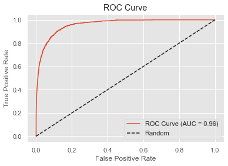

```python
# Compute predicted probabilities
y_pred_proba = best_model.predict_proba(X_test)[:, 1]

# Calculate ROC curve and AUC
fpr, tpr, thresholds = roc_curve(y_test, y_pred_proba)
auc = roc_auc_score(y_test, y_pred_proba)

# Plot ROC curve
plt.plot(fpr, tpr, label='ROC Curve (AUC = {:.2f})'.format(auc))
plt.plot([0, 1], [0, 1], 'k--', label='Random')
plt.xlabel('False Positive Rate')
plt.ylabel('True Positive Rate')
plt.title('ROC Curve')
plt.legend()
plt.show()
```

An AUC of 0.96 indicates a high level of model performance. This score suggests that the model has excellent discriminative ability in distinguishing between default and non-default instances.

# 6. Feature importance

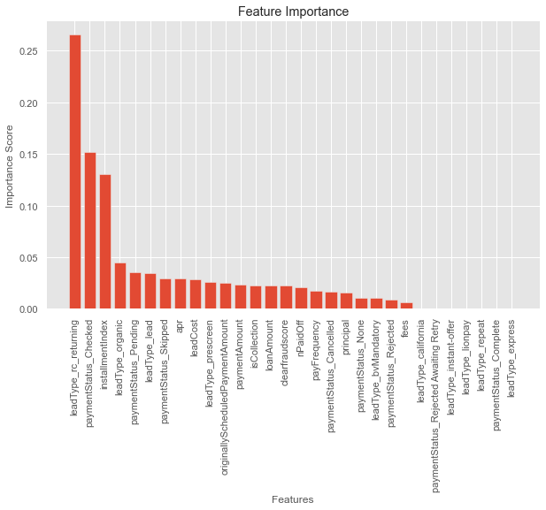

```python
# Get feature importance scores
feature_importance = best_model.feature_importances_

# Get the names of features
feature_names = X_train.columns

# Sort feature importance scores and corresponding feature names
sorted_indices = feature_importance.argsort()[::-1]
sorted_feature_importance = feature_importance[sorted_indices]
sorted_feature_names = feature_names[sorted_indices]

# Plot feature importance
plt.figure(figsize=(10, 6))
plt.bar(range(len(feature_importance)), sorted_feature_importance)
plt.xticks(range(len(feature_importance)), sorted_feature_names, rotation=90)
plt.xlabel('Features')
plt.ylabel('Importance Score')
plt.title('Feature Importance')
plt.show()
```